# 418 Homework 3

Jordan Berninger - 304872549

5/23/2017

$\textbf{Introduction to MoMA Collection dataset}$

I chose to analyze the Museum of Modern Art Collection dataset from Kaggle (https://www.kaggle.com/momanyc/museum-collection). There were two files in this dataset, artists and artworks. I joined the datasets on a shared variable (Artist.ID) and decided to model artist gender from the following variables.

```r
colnames(art.art)
```

```
## [1] "Gender"           "Date"             "Credit"
## [4] "Catalogue"        "Acquisition.Date" "Department"
## [7] "Nationality"      "Birth.Year"       "Death.Status"
```

To clean the data, I had to manipulate the Gender variable into a factor. I noticed that there were many artworks that had a blank for the artist gender. I assumed that these were pieces produced by groups, or non-binary gender artists. For the sake of simplicity and assignment constraints, I removed null gender values, so each artwork in the dataset was associated with either a Male or Femla artist. It was also necessary to do some transformation on the several Date, Acquisition.Date, Birth.Year, and Death.Year columns. They had different structures in the raw data so I converted them accordingly. I chose to create Death.Status as a boolean variable. After removing incolplete rows, I was left with the following cleaned dataset.

```r
str(art.art)
```

```
## 'data.frame':    88670 obs. of  9 variables:
##  $ Gender          : Factor w/ 2 levels "0","1": 2 2 1 2 2 2 2 2 2 2 ...
##  $ Date            : Date, format: "1977-05-24" "1986-05-24" ...
##  $ Credit          : Factor w/ 7031 levels "","[Misc.] Gift of The Judith Rothschild Foundation",..: 5046 2917 5726 5868 1987 6391 5725 5351 5351 5351 ...
##  $ Catalogue       : Factor w/ 2 levels "N","Y": 2 2 2 2 2 2 2 1 1 1 ...
##  $ Acquisition.Date: Date, format: "1981-04-28" "1997-05-28" ...
##  $ Department      : Factor w/ 9 levels "Architecture & Design",..: 3 9 9 9 7 9 7 8 8 8 ...
##  $ Nationality     : Factor w/ 126 levels "","Afghan","Albanian",..: 5 5 5 5 5 5 5 43 43 43 ...
##  $ Birth.Year      : int  1930 1930 1918 1897 1897 1897 1897 1908 1908 1908 ...
##  $ Death.Status    : Factor w/ 2 levels "0","1": 2 2 1 2 2 2 2 2 2 2 ...
##  - attr(*, "na.action")=Class 'omit'  Named int [1:27502] 8 9 47 81 98 152 250 282 337 361 ...
##   .. ..- attr(*, "names")= chr [1:27502] "8" "9" "47" "81" ...
```

```r
summary(art.art)
```

```
##  Gender         Date
##  0:12301   Min.   :0001-05-24
##  1:76369   1st Qu.:1932-05-24
##            Median :1964-05-24
##            Mean   :1956-10-16
##            3rd Qu.:1983-05-24
##            Max.   :2017-05-24
##
##                                                        Credit
##  The Louis E. Stern Collection                            :10226
##  Purchase                                                 : 6053
##  Gift of the artist                                       : 5926
##  Abbott-Levy Collection. Partial gift of Shirley C. Burden: 4487
##  Gift of the photographer                                 : 2408
##                                                           : 1866
##  (Other)                                                  :57704
##  Catalogue Acquisition.Date                          Department
##  N:39625   Min.   :1929-11-19   Prints & Illustrated Books:45161
##  Y:49045   1st Qu.:1964-10-06   Photography               :21361
##            Median :1981-02-26   Architecture & Design     : 8174
##            Mean   :1983-08-19   Drawings                  : 6354
##            3rd Qu.:2005-05-10   Painting & Sculpture      : 3246
##            Max.   :2016-12-15   Media and Performance Art : 2093
##                                 (Other)                   : 2281
##    Nationality      Birth.Year   Death.Status
##  American:39547   Min.   :1730   0:31582
##  French  :18996   1st Qu.:1887   1:57088
##  German  : 5612   Median :1918
##  British : 4267   Mean   :1912
##  Spanish : 2246   3rd Qu.:1939
##  Italian : 2137   Max.   :2000
##  (Other) :15865
```

Before running any models, I produced a lot of plots and summary statistics to familiarize myself with the data. I thought this plot was interesting:

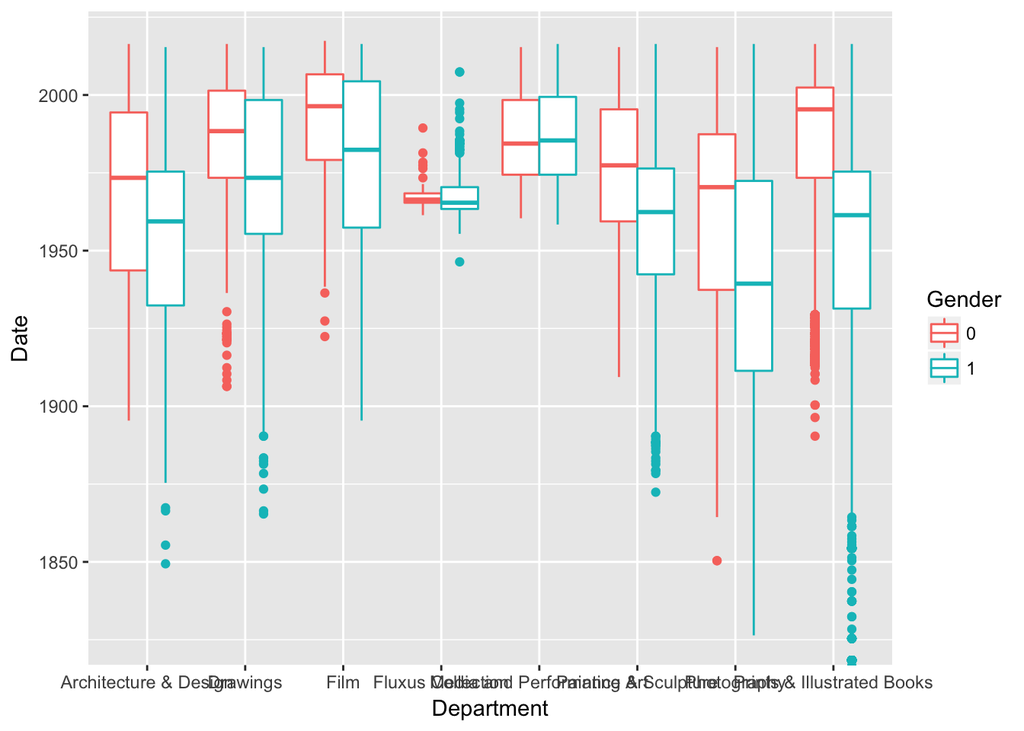

```r
ggplot(art.art, aes(x=Department, y=Date, color=Gender)) + geom_boxplot()
```

$\textbf{Logistic Regression with Lasso Regularization}$

$\textbf{glmnet}$

```
##    user  system elapsed
## 765.312   4.930 800.573
```

```
## [1] 0.5
```

First, I used the glmnet package. I trained the model on the training set, and I gave it a lambda value of .5. This model took quite a bit of time for this model to train. The AUC performance on the test data was .5.

Next, used the cv.glmnet() model in the same package to perform a cross-validated fit on the training set. The default setting for this model is a 10-fold cross validation, and if you don’t pass it an initial lambda value, it will produce give you the optimized lambda value. Because this model uses cross-validation, its prediction performance is more robust than that of a non-cross validated process. In this case the optimal lambda generated is 0.005254245, and the AUC performance on the test data was 0.855224 which is much better than that of the previous model.

```r
system.time({
  md1 <- cv.glmnet( X_train, d_train$Gender, family = "binomial")
})
```

```
##     user   system  elapsed
## 5219.542   36.423 7460.419
```

```r
## very slow

phat1 <- predict(md1, newx = X_test, type = "response")
rocr_pred1 <- prediction(phat1, d_test$Gender)
performance(rocr_pred1, "auc")@y.values[[1]]
```

```
## [1] 0.855224
```

$\textbf{h2o}$

Next, I ran the h2o implementation of logistic regression through a h2o.glm() model setting the family to binomial. h2o requires that the data be in a special format, so I used the h2o.importFile() and the h2o.splitFrame() functions to import and sample the data, respectively. This is noteworthy, because the h2o training and test datasets are the same size as the glmnet ones, but the sets are themselves different.

The h2o.glm() object has 2 parameters, alpha and lambda, that I tweaked several times for different models. These models all trained themselves in a fraction of the time of glmnet models, which was really cool. My cv.glmnet() model took a significant amount of time to train. The difference in speed is enough to make me favor h2o over glmnet, because the tool is much more agile and one can tweak the prameters and re-run with rapidity.

First, we will look at the results for the h2o.glm() model with $\alpha = 1$, $\lambda = 0$

```r
system.time({
  md_1.0 <- h2o.glm(x = Xnames, y = "Gender", training_frame = dx_train,
                family = "binomial", alpha = 1, lambda = 0)
})
```

```
##    user  system elapsed
##   0.516   0.045   6.636
```

```r
md_1.0
```

```
## Model Details:
## ==============
##
## H2OBinomialModel: glm
## Model ID:  GLM_model_R_1495661027231_1
## GLM Model: summary
##     family  link regularization number_of_predictors_total
## 1 binomial logit           None                       6596
##   number_of_active_predictors number_of_iterations  training_frame
## 1                        4980                   50 RTMP_sid_affe_2
##
## Coefficients: glm coefficients
##                                                                                                                                                                          names
## 1                                                                                                                                                                    Intercept
## 2                                                                                                                                                                  Credit.1894
## 3 Credit.1935 Acquisition confirmed in 1999 by agreement with the Estate of Kazimir Malevich and made possible with funds from the Mrs. John Hay Whitney Bequest (by exchange)
## 4                                                                                                                                                                  Credit.1936
## 5                                                                                                                                                                  Credit.1937
##   coefficients standardized_coefficients
## 1    10.818274                  2.478464
## 2     0.000000                  0.000000
## 3     0.215539                  0.215539
## 4     0.000000                  0.000000
## 5     0.000000                  0.000000
##
## ---
##                 names coefficients standardized_coefficients
## 6592               C1    -0.000010                 -0.359820
## 6593             Date    -0.000000                 -0.859362
## 6594 Acquisition.Date    -0.000000                 -0.536830
## 6595       Birth.Year     0.018396                  0.694833
## 6596       Death.Year    -0.021956                 -0.706362
## 6597     Death.Status     0.699630                  0.331885
##
## H2OBinomialMetrics: glm
## ** Reported on training data. **
##
## MSE:  0.06914325
## RMSE:  0.262951
## LogLoss:  0.2393245
```

[output cut: 13 more lines]

```
##
## Maximum Metrics: Maximum metrics at their respective thresholds
##                         metric threshold    value idx
## 1                       max f1  0.478754 0.951991 284
## 2                       max f2  0.318168 0.977591 321
## 3                 max f0point5  0.677871 0.936194 217
## 4                 max accuracy  0.496781 0.914034 280
## 5                max precision  0.999908 0.998034   0
## 6                   max recall  0.000014 1.000000 399
## 7              max specificity  0.999908 0.998347   0
## 8             max absolute_mcc  0.523035 0.587282 272
## 9   max min_per_class_accuracy  0.860890 0.804287 118
## 10 max mean_per_class_accuracy  0.867906 0.807630 114
##
## Gains/Lift Table: Extract with `h2o.gainsLift(<model>, <data>)` or `h2o.gainsLift(<model>, valid=<T/F>, xval=<T/F>)`
```

```r
h2o.auc(h2o.performance(md_1.0, dx_test))
```

```
## [1] 0.8863039
```

```r
# Plot ROC curve
h2o.performance(md_1.0, dx_test)
```

```
## H2OBinomialMetrics: glm
##
## MSE:  0.07263073
## RMSE:  0.2695009
## LogLoss:  0.2528096
## Mean Per-Class Error:  0.2896448
## AUC:  0.8863039
## Gini:  0.7726077
## R^2:  0.3977174
## Null Deviance:  37664.57
## Residual Deviance:  23484.49
## AIC:  33446.49
##
## Confusion Matrix (vertical: actual; across: predicted) for F1-optimal threshold:
##           0     1    Error         Rate
## 0      2815  3700 0.567920   =3700/6515
## 1       454 39478 0.011369   =454/39932
## Totals 3269 43178 0.089435  =4154/46447
##
## Maximum Metrics: Maximum metrics at their respective thresholds
##                         metric threshold    value idx
## 1                       max f1  0.483026 0.950018 282
## 2                       max f2  0.284149 0.976440 330
## 3                 max f0point5  0.671647 0.932773 221
## 4                 max accuracy  0.483026 0.910565 282
## 5                max precision  0.999923 0.996669   0
## 6                   max recall  0.000113 1.000000 399
## 7              max specificity  0.999923 0.997391   0
## 8             max absolute_mcc  0.522872 0.572699 271
## 9   max min_per_class_accuracy  0.864756 0.793707 120
## 10 max mean_per_class_accuracy  0.864756 0.794004 120
##
## Gains/Lift Table: Extract with `h2o.gainsLift(<model>, <data>)` or `h2o.gainsLift(<model>, valid=<T/F>, xval=<T/F>)`
```

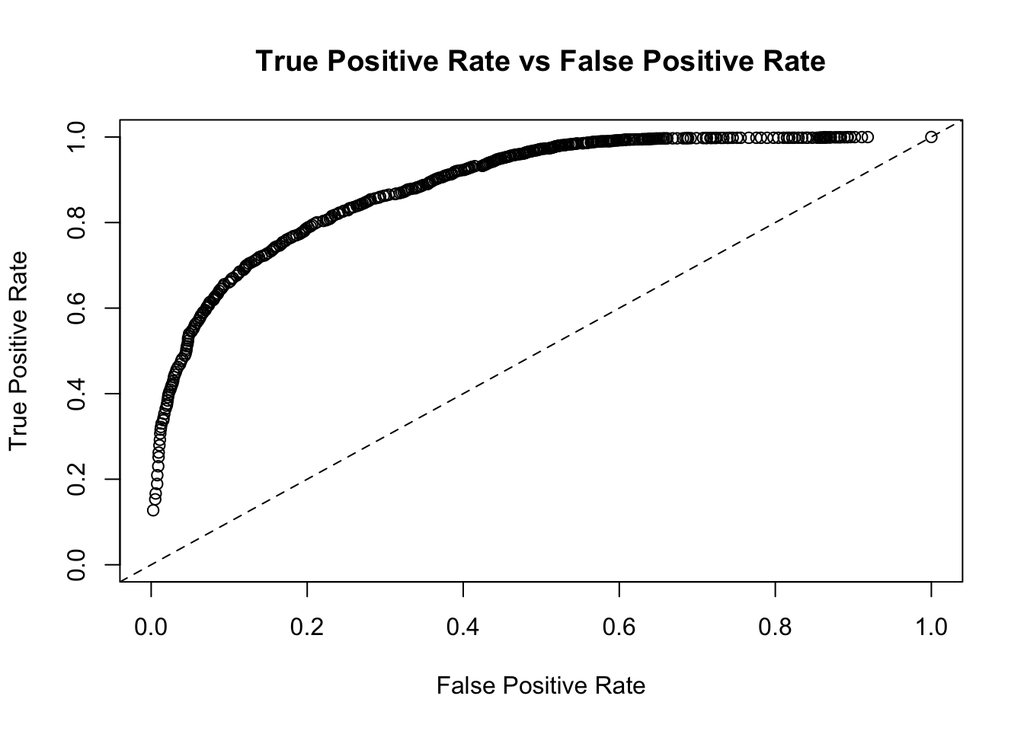

```r
plot(h2o.performance(md_1.0, dx_test), type = "roc")
```

This model had a training AUC of 0.8973 and a test AUC of 0.8863, meaning it slightly outperformed the glmnet() implementation.

Now will look at the results for the h2o.glm() model with $\alpha = 0$, $\lambda = 1$

```r
system.time({
md_0.1 <- h2o.glm(x = Xnames, y = "Gender", training_frame = dx_train,
                  family = "binomial", alpha = 0, lambda = 1)
})
```

```
##    user  system elapsed
##   0.477   0.032   1.862
```

```r
md_0.1
```

```
## Model Details:
## ==============
##
## H2OBinomialModel: glm
## Model ID:  GLM_model_R_1495661027231_6
## GLM Model: summary
##     family  link         regularization number_of_predictors_total
## 1 binomial logit Ridge ( lambda = 1.0 )                       6600
##   number_of_active_predictors number_of_iterations  training_frame
## 1                        4982                    3 RTMP_sid_affe_2
##
## Coefficients: glm coefficients
##                                                                                                                                                                          names
## 1                                                                                                                                                                    Intercept
## 2                                                                                                                                                                      Credit.
## 3                                                                                                                                                                  Credit.1894
## 4 Credit.1935 Acquisition confirmed in 1999 by agreement with the Estate of Kazimir Malevich and made possible with funds from the Mrs. John Hay Whitney Bequest (by exchange)
## 5                                                                                                                                                                  Credit.1936
##   coefficients standardized_coefficients
## 1     5.903912                  1.837602
## 2     0.000715                  0.000715
## 3     0.000000                  0.000000
## 4     0.000013                  0.000013
## 5     0.000000                  0.000000
##
## ---
##                 names coefficients standardized_coefficients
## 6596               C1    -0.000001                 -0.051961
## 6597             Date    -0.000000                 -0.037098
## 6598 Acquisition.Date    -0.000000                 -0.056368
## 6599       Birth.Year    -0.000910                 -0.034379
## 6600       Death.Year    -0.001135                 -0.036516
## 6601     Death.Status     0.031367                  0.014880
##
## H2OBinomialMetrics: glm
## ** Reported on training data. **
##
## MSE:  0.1161032
## RMSE:  0.3407392
## LogLoss:  0.3886336
```

[output cut: 13 more lines]

```
##
## Maximum Metrics: Maximum metrics at their respective thresholds
##                         metric threshold    value idx
## 1                       max f1  0.829288 0.929157 372
## 2                       max f2  0.820549 0.968776 397
## 3                 max f0point5  0.840279 0.903857 322
## 4                 max accuracy  0.829494 0.870348 371
## 5                max precision  0.970449 1.000000   0
## 6                   max recall  0.819273 1.000000 399
## 7              max specificity  0.970449 1.000000   0
## 8             max absolute_mcc  0.840972 0.309788 318
## 9   max min_per_class_accuracy  0.853386 0.666357 244
## 10 max mean_per_class_accuracy  0.849976 0.680295 266
##
## Gains/Lift Table: Extract with `h2o.gainsLift(<model>, <data>)` or `h2o.gainsLift(<model>, valid=<T/F>, xval=<T/F>)`
```

```r
h2o.auc(h2o.performance(md_0.1, dx_test))
```

```
## [1] 0.7498551
```

```r
# Plot ROC curve
h2o.performance(md_0.1, dx_test)
```

```
## H2OBinomialMetrics: glm
##
## MSE:  0.1170681
## RMSE:  0.3421522
## LogLoss:  0.3909452
## Mean Per-Class Error:  0.4365143
## AUC:  0.7498551
## Gini:  0.4997101
## R^2:  0.0292254
## Null Deviance:  37664.57
## Residual Deviance:  36316.46
## AIC:  46282.46
##
## Confusion Matrix (vertical: actual; across: predicted) for F1-optimal threshold:
##           0     1    Error         Rate
## 0       907  5608 0.860783   =5608/6515
## 1       489 39443 0.012246   =489/39932
## Totals 1396 45051 0.131268  =6097/46447
##
## Maximum Metrics: Maximum metrics at their respective thresholds
##                         metric threshold    value idx
## 1                       max f1  0.829332 0.928256 374
## 2                       max f2  0.820566 0.968471 398
## 3                 max f0point5  0.840977 0.904036 316
## 4                 max accuracy  0.829505 0.868775 373
## 5                max precision  0.969975 1.000000   0
## 6                   max recall  0.820566 1.000000 398
## 7              max specificity  0.969975 1.000000   0
## 8             max absolute_mcc  0.840977 0.318822 316
## 9   max min_per_class_accuracy  0.853286 0.669263 246
## 10 max mean_per_class_accuracy  0.849434 0.686021 269
##
## Gains/Lift Table: Extract with `h2o.gainsLift(<model>, <data>)` or `h2o.gainsLift(<model>, valid=<T/F>, xval=<T/F>)`
```

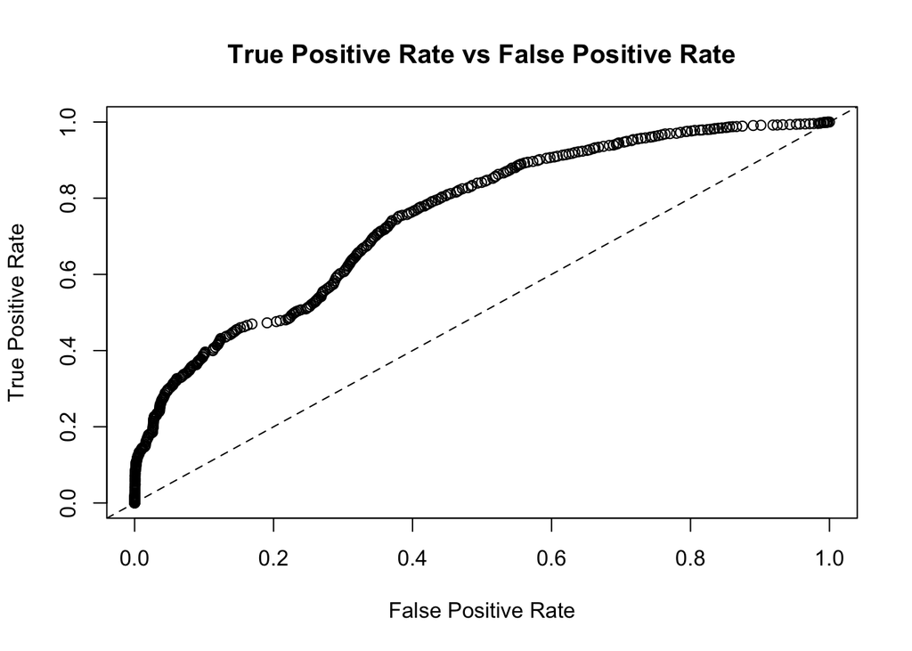

```r
plot(h2o.performance(md_0.1, dx_test), type = "roc")
```

This model did not perform as well on the training set, with an AUC of 0.7462, and on the test set, and similarily it did not perform as well on the test set, with and AUC of 0.7498. Furthermore, we can see a bump in the middleof the ROC curve, which indicates and inefficent region.

Now, results for the h2o.glm() model with $\alpha = 1$, $\lambda = 1$.

```r
system.time({
md_1.1 <- h2o.glm(x = Xnames, y = "Gender", training_frame = dx_train,
                  family = "binomial", alpha = 1, lambda = 1)
})
```

```
##    user  system elapsed
##   0.404   0.018   1.727
```

```r
## train time elapsed 2.607
md_1.1
```

```
## Model Details:
## ==============
##
## H2OBinomialModel: glm
## Model ID:  GLM_model_R_1495661027231_11
## GLM Model: summary
##     family  link        regularization number_of_predictors_total
## 1 binomial logit Lasso (lambda = 1.0 )                       6600
##   number_of_active_predictors number_of_iterations  training_frame
## 1                           0                    0 RTMP_sid_affe_2
##
## Coefficients: glm coefficients
##                                                                                                                                                                          names
## 1                                                                                                                                                                    Intercept
## 2                                                                                                                                                                      Credit.
## 3                                                                                                                                                                  Credit.1894
## 4 Credit.1935 Acquisition confirmed in 1999 by agreement with the Estate of Kazimir Malevich and made possible with funds from the Mrs. John Hay Whitney Bequest (by exchange)
## 5                                                                                                                                                                  Credit.1936
##   coefficients standardized_coefficients
## 1     1.825272                  1.825272
## 2     0.000000                  0.000000
## 3     0.000000                  0.000000
## 4     0.000000                  0.000000
## 5     0.000000                  0.000000
##
## ---
##                 names coefficients standardized_coefficients
## 6596               C1     0.000000                  0.000000
## 6597             Date     0.000000                  0.000000
## 6598 Acquisition.Date     0.000000                  0.000000
## 6599       Birth.Year     0.000000                  0.000000
## 6600       Death.Year     0.000000                  0.000000
## 6601     Death.Status     0.000000                  0.000000
##
## H2OBinomialMetrics: glm
## ** Reported on training data. **
##
## MSE:  0.1195363
## RMSE:  0.3457403
## LogLoss:  0.4027836
```

[output cut: 13 more lines]

```
##
## Maximum Metrics: Maximum metrics at their respective thresholds
##                         metric threshold    value idx
## 1                       max f1  0.861198 0.925423   0
## 2                       max f2  0.861198 0.968772   0
## 3                 max f0point5  0.861198 0.885787   0
## 4                 max accuracy  0.861198 0.861198   0
## 5                max precision  0.861198 0.861198   0
## 6                   max recall  0.861198 1.000000   0
## 7              max specificity  0.861198 0.000000   0
## 8             max absolute_mcc  0.861198 0.000000   0
## 9   max min_per_class_accuracy  0.861198 0.000000   0
## 10 max mean_per_class_accuracy  0.861198 0.500000   0
##
## Gains/Lift Table: Extract with `h2o.gainsLift(<model>, <data>)` or `h2o.gainsLift(<model>, valid=<T/F>, xval=<T/F>)`
```

```r
# train AUC:  0.5
h2o.auc(h2o.performance(md_1.1, dx_test))
```

```
## [1] 0.5
```

```r
# test AUC .5 SAME AS GLMNET performances
# Plot ROC curve
h2o.performance(md_1.1, dx_test)
```

```
## H2OBinomialMetrics: glm
##
## MSE:  0.1205946
## RMSE:  0.3472673
## LogLoss:  0.4054576
## Mean Per-Class Error:  0.5
## AUC:  0.5
## Gini:  0
## R^2:  -1.779645e-05
## Null Deviance:  37664.57
## Residual Deviance:  37664.57
## AIC:  37666.57
##
## Confusion Matrix (vertical: actual; across: predicted) for F1-optimal threshold:
##        0     1    Error         Rate
## 0      0  6515 1.000000   =6515/6515
## 1      0 39932 0.000000     =0/39932
## Totals 0 46447 0.140267  =6515/46447
##
## Maximum Metrics: Maximum metrics at their respective thresholds
##                         metric threshold    value idx
## 1                       max f1  0.861198 0.924577   0
## 2                       max f2  0.861198 0.968401   0
## 3                 max f0point5  0.861198 0.884547   0
## 4                 max accuracy  0.861198 0.859733   0
## 5                max precision  0.861198 0.859733   0
## 6                   max recall  0.861198 1.000000   0
## 7              max specificity  0.861198 0.000000   0
## 8             max absolute_mcc  0.861198 0.000000   0
## 9   max min_per_class_accuracy  0.861198 0.000000   0
## 10 max mean_per_class_accuracy  0.861198 0.500000   0
##
## Gains/Lift Table: Extract with `h2o.gainsLift(<model>, <data>)` or `h2o.gainsLift(<model>, valid=<T/F>, xval=<T/F>)`
```

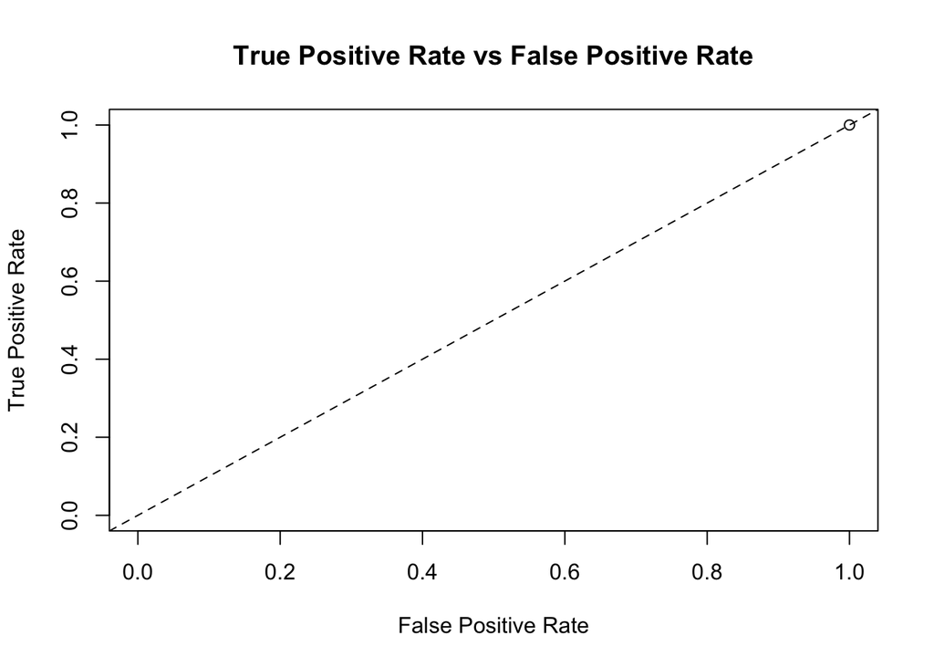

```r
plot(h2o.performance(md_1.1, dx_test), type = "roc")
```

Clearly, there is something wrong with this model, as it has both training and test AUC = .5 and a flat ROC line. I will look deeper into the nature of the case where both $\lambda = \alpha = 1$.

Out of all the logistic regression models, the one that performed the best on the training and test data was the h2o implementation of the GLM $\alpha = 1$, $\lambda = 0$. The cv.glmnet() model performed similarily on the test data, but it it significant that the code took much longer to run.

$\textbf{Random Forests}$

$\textbf{h2o}$

First, I ran severl random forests through th h2o implementation. This was very easy to do, as it has most of the same syntax as the h2o.glm() function and I can feed it the same data. I manipulated the ntrees and the max_depth parameters for several models, whichare summarized below:

100 trees and max_depth = 5

```r
system.time({
  rf_100.5 <- h2o.randomForest(x = Xnames, y = "Gender", training_frame = dx_train, ntrees = 100, max_depth=5)
})
```

```
##    user  system elapsed
##   0.350   0.018   8.597
```

```r
rf_100.5
```

```
## Model Details:
## ==============
##
## H2ORegressionModel: drf
## Model ID:  DRF_model_R_1495661027231_16
## Model Summary:
##   number_of_trees number_of_internal_trees model_size_in_bytes min_depth
## 1             100                      100            32329404         5
##   max_depth mean_depth min_leaves max_leaves mean_leaves
## 1         5    5.00000         15         32    19.72000
##
##
## H2ORegressionMetrics: drf
## ** Reported on training data. **
## ** Metrics reported on Out-Of-Bag training samples **
##
## MSE:  0.08368959
## RMSE:  0.2892915
## MAE:  0.1804541
## RMSLE:  0.2032084
## Mean Residual Deviance :  0.08368959
```

```r
h2o.auc(h2o.performance(rf_100.5, dx_test))
```

```r
h2o.mse(h2o.performance(rf_100.5, dx_test))
```

```
## [1] 0.08460775
```

Now, we will reduce the max_depth to 3 of the trees and see how it impacts performanca.

```r
system.time({
  rf_100.3 <- h2o.randomForest(x = Xnames, y = "Gender", training_frame = dx_train, ntrees = 100, max_depth=3)
})
```

```
##    user  system elapsed
##   0.323   0.017   6.630
```

```r
rf_100.3
```

```
## Model Details:
## ==============
##
## H2ORegressionModel: drf
## Model ID:  DRF_model_R_1495661027231_17
## Model Summary:
##   number_of_trees number_of_internal_trees model_size_in_bytes min_depth
## 1             100                      100            32307604         3
##   max_depth mean_depth min_leaves max_leaves mean_leaves
## 1         3    3.00000          5          8     6.44000
##
##
## H2ORegressionMetrics: drf
## ** Reported on training data. **
## ** Metrics reported on Out-Of-Bag training samples **
##
## MSE:  0.09374086
## RMSE:  0.3061713
## MAE:  0.2034768
## RMSLE:  0.2156739
## Mean Residual Deviance :  0.09374086
```

```r
h2o.auc(h2o.performance(rf_100.3, dx_test))
```

```r
h2o.mse(h2o.performance(rf_100.3, dx_test))
```

```
## [1] 0.0944718
```

Now, 200 trees and max_depth = 5.

```r
system.time({
  rf_200.5 <- h2o.randomForest(x = Xnames, y = "Gender", training_frame = dx_train, ntrees = 200, max_depth=5)
})
```

```
##    user  system elapsed
##   0.374   0.022  10.713
```

```r
rf_200.5
```

```
## Model Details:
## ==============
##
## H2ORegressionModel: drf
## Model ID:  DRF_model_R_1495661027231_18
## Model Summary:
##   number_of_trees number_of_internal_trees model_size_in_bytes min_depth
## 1             200                      200            64662346         5
##   max_depth mean_depth min_leaves max_leaves mean_leaves
## 1         5    5.00000         15         32    20.84500
##
##
## H2ORegressionMetrics: drf
## ** Reported on training data. **
## ** Metrics reported on Out-Of-Bag training samples **
##
## MSE:  0.08283757
## RMSE:  0.2878152
## MAE:  0.1784207
## RMSLE:  0.2024443
## Mean Residual Deviance :  0.08283757
```

```r
h2o.auc(h2o.performance(rf_200.5, dx_test))
```

```r
h2o.mse(h2o.performance(rf_200.5, dx_test))
```

```
## [1] 0.08377635
```

Now, 200 trees and max_depth = 3

```r
system.time({
  rf_200.3 <- h2o.randomForest(x = Xnames, y = "Gender", training_frame = dx_train, ntrees = 200, max_depth=3)
})
```

```
##    user  system elapsed
##   0.352   0.017   9.596
```

```r
rf_200.3
```

```
## Model Details:
## ==============
##
## H2ORegressionModel: drf
## Model ID:  DRF_model_R_1495661027231_19
## Model Summary:
##   number_of_trees number_of_internal_trees model_size_in_bytes min_depth
## 1             200                      200            64614624         3
##   max_depth mean_depth min_leaves max_leaves mean_leaves
## 1         3    3.00000          5          8     6.27500
##
##
## H2ORegressionMetrics: drf
## ** Reported on training data. **
## ** Metrics reported on Out-Of-Bag training samples **
##
## MSE:  0.09436274
## RMSE:  0.3071852
## MAE:  0.2046498
## RMSLE:  0.2163848
## Mean Residual Deviance :  0.09436274
```

```r
h2o.auc(h2o.performance(rf_200.3, dx_test))
```

```r
h2o.mse(h2o.performance(rf_200.3, dx_test))
```

```
## [1] 0.09522173
```

$\textbf{xgboost}$

Next, I ran the xgboost implementation of a random forest model. I fed the model the same combinations of parameters, but it is worth noting that there were several parameters that I passed to these models as constants, specifically, I specified, but did not change, the subsample parameter.

100 trees and max depth = 5

```r
system.time({
  n_proc <- parallel::detectCores()
  xgb_100.5 <- xgboost(data = X_train, label = d_train$Gender,
                nthread = n_proc, nround = 1, max_depth = 5,
                num_parallel_tree = 100, subsample = 0.632,
                colsample_bytree = 1/sqrt(length(X_train@x)/nrow(X_train)),
                save_period = NULL)
})
```

```
##    user  system elapsed
##   1.829   0.024   2.191
```

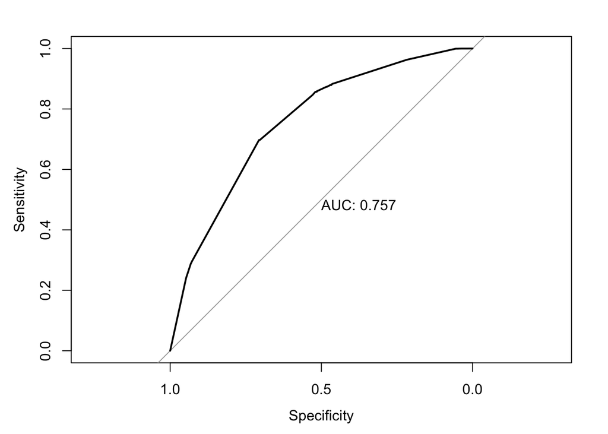

```r
phat.xgb_100.5 <- predict(xgb_100.5, newdata = X_test)
## Plot the ROC curve
plot.roc(d_test$Gender, phat.xgb_100.5, print.auc=T, print.auc.y=0.5)
```

```r
rocr_pred.xgb_100.5 <- prediction(phat.xgb_100.5, d_test$Gender)
performance(rocr_pred.xgb_100.5, "auc")@y.values[[1]]
```

```
## [1] 0.7565626
```

100 trees and max depth = 3

```r
system.time({
  n_proc <- parallel::detectCores()
  xgb_100.3 <- xgboost(data = X_train, label = d_train$Gender,
                nthread = n_proc, nround = 1, max_depth = 3,
                num_parallel_tree = 100, subsample = 0.632,
                colsample_bytree = 1/sqrt(length(X_train@x)/nrow(X_train)),
                save_period = NULL)
})
```

```
##    user  system elapsed
##   1.216   0.019   1.327
```

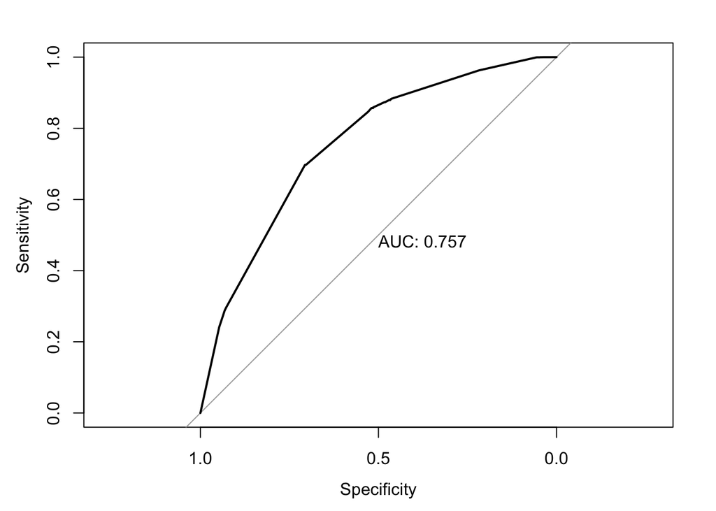

```r
phat.xgb_100.3 <- predict(xgb_100.5, newdata = X_test)
## Plot the ROC curve
plot.roc(d_test$Gender, phat.xgb_100.5, print.auc=T, print.auc.y=0.5)
```

```r
rocr_pred.xgb_100.3 <- prediction(phat.xgb_100.3, d_test$Gender)
performance(rocr_pred.xgb_100.3, "auc")@y.values[[1]]
```

```
## [1] 0.7565626
```

200 trees and max depth = 5

```r
system.time({
  n_proc <- parallel::detectCores()
  xgb_200.5 <- xgboost(data = X_train, label = d_train$Gender,
                nthread = n_proc, nround = 1, max_depth = 5,
                num_parallel_tree = 200, subsample = 0.632,
                colsample_bytree = 1/sqrt(length(X_train@x)/nrow(X_train)),
                save_period = NULL)
})
```

```
##    user  system elapsed
##   3.540   0.031   3.766
```

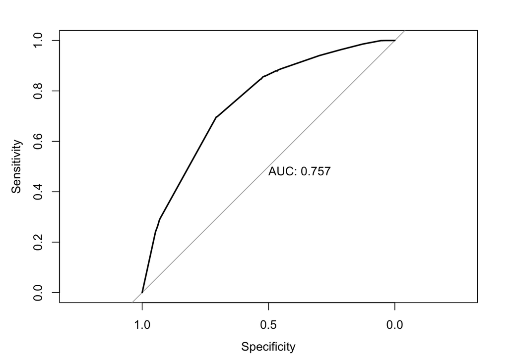

```r
phat.xgb_200.5 <- predict(xgb_200.5, newdata = X_test)
## Plot the ROC curve
plot.roc(d_test$Gender, phat.xgb_200.5, print.auc=T, print.auc.y=0.5)
```

```r
rocr_pred.xgb_200.5 <- prediction(phat.xgb_200.5, d_test$Gender)
performance(rocr_pred.xgb_200.5, "auc")@y.values[[1]]
```

```
## [1] 0.7573553
```

200 trees and max depth = 3

```r
system.time({
  n_proc <- parallel::detectCores()
  xgb_200.3 <- xgboost(data = X_train, label = d_train$Gender,
                nthread = n_proc, nround = 1, max_depth = 3,
                num_parallel_tree = 200, subsample = 0.632,
                colsample_bytree = 1/sqrt(length(X_train@x)/nrow(X_train)),
                save_period = NULL)
})
```

```
##    user  system elapsed
##   2.394   0.025   2.625
```

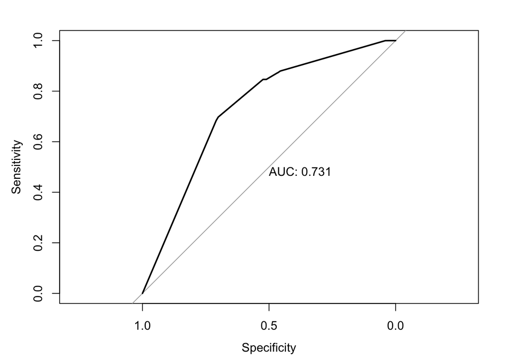

```r
# trian time elapsed 22.993
phat.xgb_200.3 <- predict(xgb_200.3, newdata = X_test)
## Plot the ROC curve
plot.roc(d_test$Gender, phat.xgb_200.3, print.auc=T, print.auc.y=0.5)
```

```r
rocr_pred.xgb_200.3 <- prediction(phat.xgb_200.3, d_test$Gender)
performance(rocr_pred.xgb_200.3, "auc")@y.values[[1]]
```

```
## [1] 0.7309453
```

We can see that all of the xgboost models performed similarily on the test data. I am not sure how to get the performance metrics for these models on the training data, however, which is frustrating. I also cannot pull the MSE from these models, so I have no comparison metric between xgboost an h2o.glm models. I will continue to plug away on this.

Overall, I think that the h2o implementation is really great in terms of ease of use. You can easily run different models on the same objects and compare performance. xgboost is nice, and it seems to perform well, but it requires a bit more code, or parameters in particular. Furthermore, it is harder to compare an xgboost model to other machine learning models, as you may have to wrangle the data differently and you may not be able to regularize the many parameters.

$\textbf{Gradient Boosting Machine}$

$\textbf{h2o}$

```r
system.time({
  gbm1 <- h2o.gbm(x = Xnames, y = "Gender", training_frame = dx_train,
                    ntrees = 100, max_depth = 3, min_rows = 2)
})
```

```
##    user  system elapsed
##   0.437   0.027  14.024
```

```r
gbm1
```

```
## Model Details:
## ==============
##
## H2ORegressionModel: gbm
## Model ID:  GBM_model_R_1495661027231_20
## Model Summary:
##   number_of_trees number_of_internal_trees model_size_in_bytes min_depth
## 1             100                      100            32311501         3
##   max_depth mean_depth min_leaves max_leaves mean_leaves
## 1         3    3.00000          7          8     7.97000
##
##
## H2ORegressionMetrics: gbm
## ** Reported on training data. **
##
## MSE:  0.06466321
## RMSE:  0.2542896
## MAE:  0.1457116
## RMSLE:  0.1802424
## Mean Residual Deviance :  0.06466321
```

```r
h2o.mse(h2o.performance(gbm1, dx_test))
```

```
## [1] 0.06657233
```

```r
h2o.auc(h2o.performance(gbm1, dx_test))
```

```r
h2o.performance(gbm1, dx_test)
```

```
## H2ORegressionMetrics: gbm
##
## MSE:  0.06657233
## RMSE:  0.2580161
## MAE:  0.147439
## RMSLE:  0.1828229
## Mean Residual Deviance :  0.06657233
```

```r
#system.time({
#  gbm2 <- h2o.gbm(x = Xnames, y = "Gender", training_frame = dx_train,
#                    ntrees = 100, max_depth = 5, min_rows = 3)
#})
#gbm2

#h2o.mse(h2o.performance(gbm2, dx_test))

#h2o.performance(gbm2, dx_test)
```

```r
#system.time({
#  gbm3 <- h2o.gbm(x = Xnames, y = "Gender", training_frame = dx_train,
#                    ntrees = 100, max_depth = 5, min_rows = 3, learn_rate = .5)
#})
#gbm3

#h2o.mse(h2o.performance(gbm3, dx_test))

#h2o.performance(gbm3, dx_test)
```

```r
#system.time({
#  gbm4 <- h2o.gbm(x = Xnames, y = "Gender", training_frame = dx_train,
#                    ntrees = 100, max_depth = 5, min_rows = 3, learn_rate = .05)
#})
#gbm4

#h2o.mse(h2o.performance(gbm4, dx_test))

#h2o.performance(gbm4, dx_test)
```

I tried manipulating the stopping parameter, but my machine seems to lack sufficient resources. I will try and run thid code on a more powerful system at school, but I am not sure if I will be able to complete this by noon.

$\textbf{Conclusions}$

It was nice to get some code up and running, and to process test datasets through trained models. I think it was a productive exercise, but I definitely ran into some issuse with finding common comparison metrics. I think I have lots to learn, but I think this was a solid step. I plan on working through the issues I experienced on this assignment with my classmates and on my own time.